# Risk Factor Analysis

## Outcome Variable

**Outcome Variable:** ever_stunted

## Predictor Variables

**Intervention Variable:** fage

**Adjustment Set:**

- arm
- W_mage
- meducyrs
- feducyrs
- W_mhtcm
- W_mwtkg
- W_mbmi
- W_fhtcm
- single
- brthmon
- delta_W_mage
- delta_meducyrs
- delta_feducyrs
- delta_W_mhtcm
- delta_W_mwtkg
- delta_W_mbmi
- delta_W_fhtcm
- delta_single
- delta_brthmon

## Stratifying Variables

The analysis was stratified on these variable(s):

- agecat
- studyid
- country

## Data Summary

| agecat | studyid | country | fage | ever_stunted | n_cell | n |
| --- | --- | --- | --- | --- | --- | --- |
| 0-24 months | ki0047075b-MAL-ED | BANGLADESH | >=38 | 0 | 27 | 151 |
| 0-24 months | ki0047075b-MAL-ED | BANGLADESH | >=38 | 1 | 42 | 151 |
| 0-24 months | ki0047075b-MAL-ED | BANGLADESH | <32 | 0 | 7 | 151 |
| 0-24 months | ki0047075b-MAL-ED | BANGLADESH | <32 | 1 | 23 | 151 |
| 0-24 months | ki0047075b-MAL-ED | BANGLADESH | [32-38) | 0 | 23 | 151 |
| 0-24 months | ki0047075b-MAL-ED | BANGLADESH | [32-38) | 1 | 29 | 151 |
| 0-24 months | ki0047075b-MAL-ED | BRAZIL | >=38 | 0 | 21 | 79 |
| 0-24 months | ki0047075b-MAL-ED | BRAZIL | >=38 | 1 | 9 | 79 |
| 0-24 months | ki0047075b-MAL-ED | BRAZIL | <32 | 0 | 8 | 79 |
| 0-24 months | ki0047075b-MAL-ED | BRAZIL | <32 | 1 | 10 | 79 |
| 0-24 months | ki0047075b-MAL-ED | BRAZIL | [32-38) | 0 | 25 | 79 |
| 0-24 months | ki0047075b-MAL-ED | BRAZIL | [32-38) | 1 | 6 | 79 |
| 0-24 months | ki0047075b-MAL-ED | INDIA | >=38 | 0 | 16 | 161 |
| 0-24 months | ki0047075b-MAL-ED | INDIA | >=38 | 1 | 20 | 161 |
| 0-24 months | ki0047075b-MAL-ED | INDIA | <32 | 0 | 18 | 161 |
| 0-24 months | ki0047075b-MAL-ED | INDIA | <32 | 1 | 35 | 161 |
| 0-24 months | ki0047075b-MAL-ED | INDIA | [32-38) | 0 | 24 | 161 |
| 0-24 months | ki0047075b-MAL-ED | INDIA | [32-38) | 1 | 48 | 161 |
| 0-24 months | ki0047075b-MAL-ED | NEPAL | >=38 | 0 | 12 | 79 |
| 0-24 months | ki0047075b-MAL-ED | NEPAL | >=38 | 1 | 5 | 79 |
| 0-24 months | ki0047075b-MAL-ED | NEPAL | <32 | 0 | 9 | 79 |
| 0-24 months | ki0047075b-MAL-ED | NEPAL | <32 | 1 | 6 | 79 |
| 0-24 months | ki0047075b-MAL-ED | NEPAL | [32-38) | 0 | 28 | 79 |
| 0-24 months | ki0047075b-MAL-ED | NEPAL | [32-38) | 1 | 19 | 79 |
| 0-24 months | ki0047075b-MAL-ED | PERU | >=38 | 0 | 10 | 85 |
| 0-24 months | ki0047075b-MAL-ED | PERU | >=38 | 1 | 17 | 85 |
| 0-24 months | ki0047075b-MAL-ED | PERU | <32 | 0 | 8 | 85 |
| 0-24 months | ki0047075b-MAL-ED | PERU | <32 | 1 | 21 | 85 |
| 0-24 months | ki0047075b-MAL-ED | PERU | [32-38) | 0 | 7 | 85 |
| 0-24 months | ki0047075b-MAL-ED | PERU | [32-38) | 1 | 22 | 85 |

[output cut: 204 more lines]

The following strata were considered:

- agecat: 0-24 months, studyid: ki0047075b-MAL-ED, country: BANGLADESH
- agecat: 0-24 months, studyid: ki0047075b-MAL-ED, country: BRAZIL
- agecat: 0-24 months, studyid: ki0047075b-MAL-ED, country: INDIA
- agecat: 0-24 months, studyid: ki0047075b-MAL-ED, country: NEPAL
- agecat: 0-24 months, studyid: ki0047075b-MAL-ED, country: PERU
- agecat: 0-24 months, studyid: ki0047075b-MAL-ED, country: SOUTH AFRICA
- agecat: 0-24 months, studyid: ki0047075b-MAL-ED, country: TANZANIA, UNITED REPUBLIC OF
- agecat: 0-24 months, studyid: ki1000304b-SAS-CompFeed, country: INDIA
- agecat: 0-24 months, studyid: ki1000304b-SAS-FoodSuppl, country: INDIA
- agecat: 0-24 months, studyid: ki1119695-PROBIT, country: BELARUS
- agecat: 0-24 months, studyid: ki1135781-COHORTS, country: GUATEMALA
- agecat: 0-24 months, studyid: ki1135781-COHORTS, country: PHILIPPINES
- agecat: 0-24 months, studyid: ki1148112-LCNI-5, country: MALAWI
- agecat: 0-6 months, studyid: ki0047075b-MAL-ED, country: BANGLADESH
- agecat: 0-6 months, studyid: ki0047075b-MAL-ED, country: BRAZIL
- agecat: 0-6 months, studyid: ki0047075b-MAL-ED, country: INDIA
- agecat: 0-6 months, studyid: ki0047075b-MAL-ED, country: NEPAL
- agecat: 0-6 months, studyid: ki0047075b-MAL-ED, country: PERU
- agecat: 0-6 months, studyid: ki0047075b-MAL-ED, country: SOUTH AFRICA
- agecat: 0-6 months, studyid: ki0047075b-MAL-ED, country: TANZANIA, UNITED REPUBLIC OF
- agecat: 0-6 months, studyid: ki1000304b-SAS-CompFeed, country: INDIA
- agecat: 0-6 months, studyid: ki1000304b-SAS-FoodSuppl, country: INDIA
- agecat: 0-6 months, studyid: ki1119695-PROBIT, country: BELARUS
- agecat: 0-6 months, studyid: ki1135781-COHORTS, country: GUATEMALA
- agecat: 0-6 months, studyid: ki1135781-COHORTS, country: PHILIPPINES
- agecat: 0-6 months, studyid: ki1148112-LCNI-5, country: MALAWI
- agecat: 6-24 months, studyid: ki0047075b-MAL-ED, country: BANGLADESH
- agecat: 6-24 months, studyid: ki0047075b-MAL-ED, country: BRAZIL
- agecat: 6-24 months, studyid: ki0047075b-MAL-ED, country: INDIA
- agecat: 6-24 months, studyid: ki0047075b-MAL-ED, country: NEPAL
- agecat: 6-24 months, studyid: ki0047075b-MAL-ED, country: PERU
- agecat: 6-24 months, studyid: ki0047075b-MAL-ED, country: SOUTH AFRICA
- agecat: 6-24 months, studyid: ki0047075b-MAL-ED, country: TANZANIA, UNITED REPUBLIC OF
- agecat: 6-24 months, studyid: ki1000304b-SAS-CompFeed, country: INDIA
- agecat: 6-24 months, studyid: ki1000304b-SAS-FoodSuppl, country: INDIA
- agecat: 6-24 months, studyid: ki1119695-PROBIT, country: BELARUS
- agecat: 6-24 months, studyid: ki1135781-COHORTS, country: GUATEMALA
- agecat: 6-24 months, studyid: ki1135781-COHORTS, country: PHILIPPINES
- agecat: 6-24 months, studyid: ki1148112-LCNI-5, country: MALAWI

### Dropped Strata

Some strata were dropped due to rare outcomes:

- agecat: 0-24 months, studyid: ki0047075b-MAL-ED, country: SOUTH AFRICA
- agecat: 0-24 months, studyid: ki0047075b-MAL-ED, country: TANZANIA, UNITED REPUBLIC OF
- agecat: 0-6 months, studyid: ki0047075b-MAL-ED, country: NEPAL
- agecat: 0-6 months, studyid: ki0047075b-MAL-ED, country: SOUTH AFRICA
- agecat: 0-6 months, studyid: ki1148112-LCNI-5, country: MALAWI
- agecat: 6-24 months, studyid: ki0047075b-MAL-ED, country: BRAZIL
- agecat: 6-24 months, studyid: ki0047075b-MAL-ED, country: NEPAL
- agecat: 6-24 months, studyid: ki0047075b-MAL-ED, country: PERU
- agecat: 6-24 months, studyid: ki0047075b-MAL-ED, country: SOUTH AFRICA
- agecat: 6-24 months, studyid: ki0047075b-MAL-ED, country: TANZANIA, UNITED REPUBLIC OF

## Methods Detail

We’re interested in the causal parameters $E[Y_a]$ for all values of $a \in \mathcal{A}$. These parameters represent the mean outcome if, possibly contrary to fact, we intervened to set all units to have $A=a$. Under the randomization and positivity assumptions, these are identified by the statistical parameters $\psi_a=E_W[E_{Y|A,W}(Y|A=a,W)]$. In addition, we’re interested in the mean of $Y$, $E[Y]$ under no intervention (the observed mean). We will estimate these parameters by using SuperLearner to fit the relevant likelihood factors – $E_{Y|A,W}(Y|A=a,W)$ and $p(A=a|W)$, and then updating our likelihood fit using a joint TMLE.

For unadjusted analyses ($W=\{\}$), initial likelihoods were estimated using Lrnr_glm to estimate the simple $E(Y|A)$ and Lrnr_mean to estimate $p(A)$. For adjusted analyses, a small library containing Lrnr_glmnet, Lrnr_xgboost, and Lrnr_mean was used.

Having estimated these parameters, we will then use the delta method to estimate relative risks and attributable risks relative to a prespecified baseline level of $A$.

# Results Detail

## Results Plots

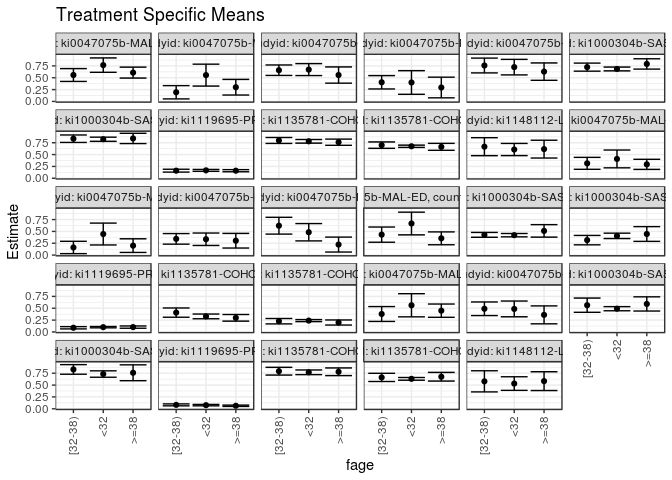

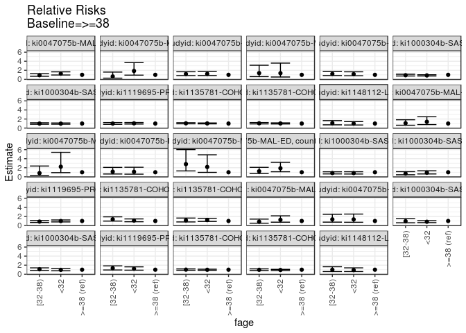

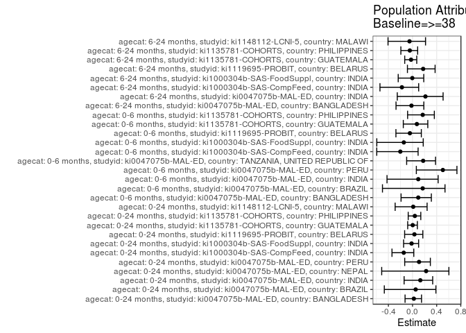

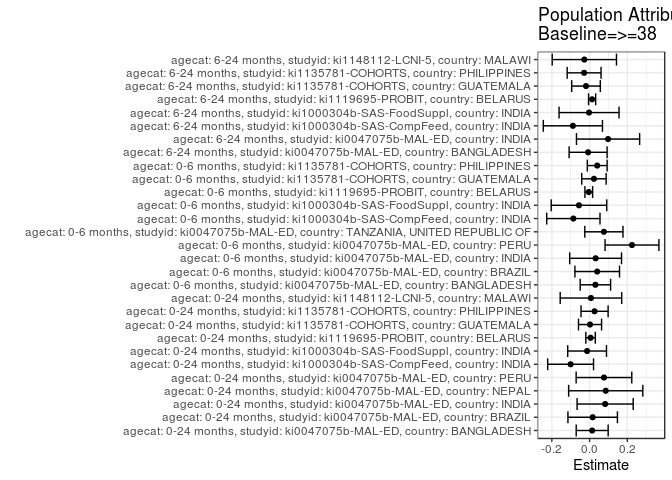

## Results Table

### Parameter: TSM

| agecat | studyid | country | intervention_level | baseline_level | estimate | ci_lower | ci_upper |
| --- | --- | --- | --- | --- | --- | --- | --- |
| 0-24 months | ki0047075b-MAL-ED | BANGLADESH | >=38 | NA | 0.6086957 | 0.4931579 | 0.7242334 |
| 0-24 months | ki0047075b-MAL-ED | BANGLADESH | <32 | NA | 0.7666667 | 0.6148142 | 0.9185192 |
| 0-24 months | ki0047075b-MAL-ED | BANGLADESH | [32-38) | NA | 0.5576923 | 0.4222517 | 0.6931329 |
| 0-24 months | ki0047075b-MAL-ED | BRAZIL | >=38 | NA | 0.3000000 | 0.1349698 | 0.4650302 |
| 0-24 months | ki0047075b-MAL-ED | BRAZIL | <32 | NA | 0.5555556 | 0.3245350 | 0.7865761 |
| 0-24 months | ki0047075b-MAL-ED | BRAZIL | [32-38) | NA | 0.1935484 | 0.0535840 | 0.3335127 |
| 0-24 months | ki0047075b-MAL-ED | INDIA | >=38 | NA | 0.5571831 | 0.3859164 | 0.7284498 |
| 0-24 months | ki0047075b-MAL-ED | INDIA | <32 | NA | 0.6722756 | 0.5457876 | 0.7987637 |
| 0-24 months | ki0047075b-MAL-ED | INDIA | [32-38) | NA | 0.6593800 | 0.5491734 | 0.7695867 |
| 0-24 months | ki0047075b-MAL-ED | NEPAL | >=38 | NA | 0.2941176 | 0.0761377 | 0.5120976 |
| 0-24 months | ki0047075b-MAL-ED | NEPAL | <32 | NA | 0.4000000 | 0.1504978 | 0.6495022 |
| 0-24 months | ki0047075b-MAL-ED | NEPAL | [32-38) | NA | 0.4042553 | 0.2630590 | 0.5454516 |
| 0-24 months | ki0047075b-MAL-ED | PERU | >=38 | NA | 0.6296296 | 0.4463996 | 0.8128597 |
| 0-24 months | ki0047075b-MAL-ED | PERU | <32 | NA | 0.7241379 | 0.5605032 | 0.8877727 |
| 0-24 months | ki0047075b-MAL-ED | PERU | [32-38) | NA | 0.7586207 | 0.6019523 | 0.9152890 |
| 0-24 months | ki1000304b-SAS-CompFeed | INDIA | >=38 | NA | 0.7914317 | 0.6823930 | 0.9004703 |
| 0-24 months | ki1000304b-SAS-CompFeed | INDIA | <32 | NA | 0.6855379 | 0.6454157 | 0.7256602 |
| 0-24 months | ki1000304b-SAS-CompFeed | INDIA | [32-38) | NA | 0.7241549 | 0.6389630 | 0.8093468 |
| 0-24 months | ki1000304b-SAS-FoodSuppl | INDIA | >=38 | NA | 0.8409091 | 0.7327061 | 0.9491120 |
| 0-24 months | ki1000304b-SAS-FoodSuppl | INDIA | <32 | NA | 0.8235294 | 0.7795251 | 0.8675337 |
| 0-24 months | ki1000304b-SAS-FoodSuppl | INDIA | [32-38) | NA | 0.8352941 | 0.7563476 | 0.9142406 |
| 0-24 months | ki1119695-PROBIT | BELARUS | >=38 | NA | 0.1600055 | 0.1374095 | 0.1826016 |
| 0-24 months | ki1119695-PROBIT | BELARUS | <32 | NA | 0.1670850 | 0.1473091 | 0.1868609 |
| 0-24 months | ki1119695-PROBIT | BELARUS | [32-38) | NA | 0.1602662 | 0.1299520 | 0.1905804 |
| 0-24 months | ki1135781-COHORTS | GUATEMALA | >=38 | NA | 0.7615842 | 0.6961100 | 0.8270583 |
| 0-24 months | ki1135781-COHORTS | GUATEMALA | <32 | NA | 0.7799562 | 0.7416918 | 0.8182207 |
| 0-24 months | ki1135781-COHORTS | GUATEMALA | [32-38) | NA | 0.7980115 | 0.7352293 | 0.8607937 |
| 0-24 months | ki1135781-COHORTS | PHILIPPINES | >=38 | NA | 0.6631540 | 0.5899447 | 0.7363633 |
| 0-24 months | ki1135781-COHORTS | PHILIPPINES | <32 | NA | 0.6755193 | 0.6517555 | 0.6992831 |
| 0-24 months | ki1135781-COHORTS | PHILIPPINES | [32-38) | NA | 0.6994018 | 0.6318120 | 0.7669917 |

[output cut: 57 more lines]

### Parameter: E(Y)

| agecat | studyid | country | intervention_level | baseline_level | estimate | ci_lower | ci_upper |
| --- | --- | --- | --- | --- | --- | --- | --- |
| 0-24 months | ki0047075b-MAL-ED | BANGLADESH | NA | NA | 0.6225166 | 0.5449406 | 0.7000925 |
| 0-24 months | ki0047075b-MAL-ED | BRAZIL | NA | NA | 0.3164557 | 0.2132412 | 0.4196702 |
| 0-24 months | ki0047075b-MAL-ED | INDIA | NA | NA | 0.6397516 | 0.5653649 | 0.7141382 |
| 0-24 months | ki0047075b-MAL-ED | NEPAL | NA | NA | 0.3797468 | 0.2720427 | 0.4874510 |
| 0-24 months | ki0047075b-MAL-ED | PERU | NA | NA | 0.7058824 | 0.6084428 | 0.8033219 |
| 0-24 months | ki1000304b-SAS-CompFeed | INDIA | NA | NA | 0.6908497 | 0.6505448 | 0.7311545 |
| 0-24 months | ki1000304b-SAS-FoodSuppl | INDIA | NA | NA | 0.8277512 | 0.7915095 | 0.8639929 |
| 0-24 months | ki1119695-PROBIT | BELARUS | NA | NA | 0.1652639 | 0.1464443 | 0.1840835 |
| 0-24 months | ki1135781-COHORTS | GUATEMALA | NA | NA | 0.7640277 | 0.7409463 | 0.7871090 |
| 0-24 months | ki1135781-COHORTS | PHILIPPINES | NA | NA | 0.6895967 | 0.6729013 | 0.7062922 |
| 0-24 months | ki1148112-LCNI-5 | MALAWI | NA | NA | 0.6226415 | 0.5299266 | 0.7153564 |
| 0-6 months | ki0047075b-MAL-ED | BANGLADESH | NA | NA | 0.3245033 | 0.2495788 | 0.3994278 |
| 0-6 months | ki0047075b-MAL-ED | BRAZIL | NA | NA | 0.2405063 | 0.1456588 | 0.3353539 |
| 0-6 months | ki0047075b-MAL-ED | INDIA | NA | NA | 0.3354037 | 0.2622476 | 0.4085599 |
| 0-6 months | ki0047075b-MAL-ED | PERU | NA | NA | 0.4470588 | 0.3407351 | 0.5533826 |
| 0-6 months | ki0047075b-MAL-ED | TANZANIA, UNITED REPUBLIC OF | NA | NA | 0.4300000 | 0.3324781 | 0.5275219 |
| 0-6 months | ki1000304b-SAS-CompFeed | INDIA | NA | NA | 0.4250164 | 0.3969651 | 0.4530677 |
| 0-6 months | ki1000304b-SAS-FoodSuppl | INDIA | NA | NA | 0.3894231 | 0.3425088 | 0.4363374 |
| 0-6 months | ki1119695-PROBIT | BELARUS | NA | NA | 0.0977693 | 0.0847778 | 0.1107608 |
| 0-6 months | ki1135781-COHORTS | GUATEMALA | NA | NA | 0.3212928 | 0.2930610 | 0.3495246 |
| 0-6 months | ki1135781-COHORTS | PHILIPPINES | NA | NA | 0.2392409 | 0.2238460 | 0.2546359 |
| 6-24 months | ki0047075b-MAL-ED | BANGLADESH | NA | NA | 0.4411765 | 0.3443418 | 0.5380111 |
| 6-24 months | ki0047075b-MAL-ED | INDIA | NA | NA | 0.4579439 | 0.3630970 | 0.5527909 |
| 6-24 months | ki1000304b-SAS-CompFeed | INDIA | NA | NA | 0.5024631 | 0.4586872 | 0.5462389 |
| 6-24 months | ki1000304b-SAS-FoodSuppl | INDIA | NA | NA | 0.7572016 | 0.7031798 | 0.8112234 |
| 6-24 months | ki1119695-PROBIT | BELARUS | NA | NA | 0.0761449 | 0.0622450 | 0.0900449 |
| 6-24 months | ki1135781-COHORTS | GUATEMALA | NA | NA | 0.7619048 | 0.7334389 | 0.7903706 |
| 6-24 months | ki1135781-COHORTS | PHILIPPINES | NA | NA | 0.6470302 | 0.6263581 | 0.6677023 |
| 6-24 months | ki1148112-LCNI-5 | MALAWI | NA | NA | 0.5555556 | 0.4523209 | 0.6587902 |

### Parameter: RR

| agecat | studyid | country | intervention_level | baseline_level | estimate | ci_lower | ci_upper |
| --- | --- | --- | --- | --- | --- | --- | --- |
| 0-24 months | ki0047075b-MAL-ED | BANGLADESH | >=38 | >=38 | 1.0000000 | 1.0000000 | 1.000000 |
| 0-24 months | ki0047075b-MAL-ED | BANGLADESH | <32 | >=38 | 1.2595238 | 0.9573355 | 1.657099 |
| 0-24 months | ki0047075b-MAL-ED | BANGLADESH | [32-38) | >=38 | 0.9162088 | 0.6731774 | 1.246980 |
| 0-24 months | ki0047075b-MAL-ED | BRAZIL | >=38 | >=38 | 1.0000000 | 1.0000000 | 1.000000 |
| 0-24 months | ki0047075b-MAL-ED | BRAZIL | <32 | >=38 | 1.8518519 | 0.9292277 | 3.690543 |
| 0-24 months | ki0047075b-MAL-ED | BRAZIL | [32-38) | >=38 | 0.6451613 | 0.2600567 | 1.600548 |
| 0-24 months | ki0047075b-MAL-ED | INDIA | >=38 | >=38 | 1.0000000 | 1.0000000 | 1.000000 |
| 0-24 months | ki0047075b-MAL-ED | INDIA | <32 | >=38 | 1.2065614 | 0.8428514 | 1.727221 |
| 0-24 months | ki0047075b-MAL-ED | INDIA | [32-38) | >=38 | 1.1834171 | 0.8348566 | 1.677505 |
| 0-24 months | ki0047075b-MAL-ED | NEPAL | >=38 | >=38 | 1.0000000 | 1.0000000 | 1.000000 |
| 0-24 months | ki0047075b-MAL-ED | NEPAL | <32 | >=38 | 1.3600000 | 0.5162322 | 3.582884 |
| 0-24 months | ki0047075b-MAL-ED | NEPAL | [32-38) | >=38 | 1.3744681 | 0.6057768 | 3.118578 |
| 0-24 months | ki0047075b-MAL-ED | PERU | >=38 | >=38 | 1.0000000 | 1.0000000 | 1.000000 |
| 0-24 months | ki0047075b-MAL-ED | PERU | <32 | >=38 | 1.1501014 | 0.7956510 | 1.662454 |
| 0-24 months | ki0047075b-MAL-ED | PERU | [32-38) | >=38 | 1.2048682 | 0.8432651 | 1.721531 |
| 0-24 months | ki1000304b-SAS-CompFeed | INDIA | >=38 | >=38 | 1.0000000 | 1.0000000 | 1.000000 |
| 0-24 months | ki1000304b-SAS-CompFeed | INDIA | <32 | >=38 | 0.8661998 | 0.7411588 | 1.012336 |
| 0-24 months | ki1000304b-SAS-CompFeed | INDIA | [32-38) | >=38 | 0.9149936 | 0.7413302 | 1.129339 |
| 0-24 months | ki1000304b-SAS-FoodSuppl | INDIA | >=38 | >=38 | 1.0000000 | 1.0000000 | 1.000000 |
| 0-24 months | ki1000304b-SAS-FoodSuppl | INDIA | <32 | >=38 | 0.9793323 | 0.8519635 | 1.125743 |
| 0-24 months | ki1000304b-SAS-FoodSuppl | INDIA | [32-38) | >=38 | 0.9933227 | 0.8467458 | 1.165273 |
| 0-24 months | ki1119695-PROBIT | BELARUS | >=38 | >=38 | 1.0000000 | 1.0000000 | 1.000000 |
| 0-24 months | ki1119695-PROBIT | BELARUS | <32 | >=38 | 1.0442452 | 0.8902156 | 1.224926 |
| 0-24 months | ki1119695-PROBIT | BELARUS | [32-38) | >=38 | 1.0016292 | 0.8213910 | 1.221417 |
| 0-24 months | ki1135781-COHORTS | GUATEMALA | >=38 | >=38 | 1.0000000 | 1.0000000 | 1.000000 |
| 0-24 months | ki1135781-COHORTS | GUATEMALA | <32 | >=38 | 1.0241235 | 0.9281028 | 1.130078 |
| 0-24 months | ki1135781-COHORTS | GUATEMALA | [32-38) | >=38 | 1.0478311 | 0.9329911 | 1.176807 |
| 0-24 months | ki1135781-COHORTS | PHILIPPINES | >=38 | >=38 | 1.0000000 | 1.0000000 | 1.000000 |
| 0-24 months | ki1135781-COHORTS | PHILIPPINES | <32 | >=38 | 1.0186461 | 0.9073274 | 1.143622 |
| 0-24 months | ki1135781-COHORTS | PHILIPPINES | [32-38) | >=38 | 1.0546597 | 0.9108673 | 1.221152 |

[output cut: 57 more lines]

### Parameter: PAR

| agecat | studyid | country | intervention_level | baseline_level | estimate | ci_lower | ci_upper |
| --- | --- | --- | --- | --- | --- | --- | --- |
| 0-24 months | ki0047075b-MAL-ED | BANGLADESH | >=38 | NA | 0.0138209 | -0.0708388 | 0.0984806 |
| 0-24 months | ki0047075b-MAL-ED | BRAZIL | >=38 | NA | 0.0164557 | -0.1147061 | 0.1476175 |
| 0-24 months | ki0047075b-MAL-ED | INDIA | >=38 | NA | 0.0825684 | -0.0661279 | 0.2312648 |
| 0-24 months | ki0047075b-MAL-ED | NEPAL | >=38 | NA | 0.0856292 | -0.1110071 | 0.2822655 |
| 0-24 months | ki0047075b-MAL-ED | PERU | >=38 | NA | 0.0762527 | -0.0711882 | 0.2236936 |
| 0-24 months | ki1000304b-SAS-CompFeed | INDIA | >=38 | NA | -0.1005820 | -0.2221415 | 0.0209775 |
| 0-24 months | ki1000304b-SAS-FoodSuppl | INDIA | >=38 | NA | -0.0131579 | -0.1159028 | 0.0895870 |
| 0-24 months | ki1119695-PROBIT | BELARUS | >=38 | NA | 0.0052583 | -0.0198651 | 0.0303817 |
| 0-24 months | ki1135781-COHORTS | GUATEMALA | >=38 | NA | 0.0024435 | -0.0586925 | 0.0635795 |
| 0-24 months | ki1135781-COHORTS | PHILIPPINES | >=38 | NA | 0.0264427 | -0.0453476 | 0.0982331 |
| 0-24 months | ki1148112-LCNI-5 | MALAWI | >=38 | NA | 0.0072569 | -0.1557788 | 0.1702926 |
| 0-6 months | ki0047075b-MAL-ED | BANGLADESH | >=38 | NA | 0.0308512 | -0.0497645 | 0.1114670 |
| 0-6 months | ki0047075b-MAL-ED | BRAZIL | >=38 | NA | 0.0405063 | -0.0777589 | 0.1587716 |
| 0-6 months | ki0047075b-MAL-ED | INDIA | >=38 | NA | 0.0319394 | -0.1054442 | 0.1693230 |
| 0-6 months | ki0047075b-MAL-ED | PERU | >=38 | NA | 0.2248366 | 0.0820782 | 0.3675950 |
| 0-6 months | ki0047075b-MAL-ED | TANZANIA, UNITED REPUBLIC OF | >=38 | NA | 0.0758333 | -0.0254096 | 0.1770763 |
| 0-6 months | ki1000304b-SAS-CompFeed | INDIA | >=38 | NA | -0.0859847 | -0.2272332 | 0.0552639 |
| 0-6 months | ki1000304b-SAS-FoodSuppl | INDIA | >=38 | NA | -0.0562209 | -0.2034507 | 0.0910088 |
| 0-6 months | ki1119695-PROBIT | BELARUS | >=38 | NA | -0.0042641 | -0.0246806 | 0.0161525 |
| 0-6 months | ki1135781-COHORTS | GUATEMALA | >=38 | NA | 0.0231363 | -0.0415970 | 0.0878696 |
| 0-6 months | ki1135781-COHORTS | PHILIPPINES | >=38 | NA | 0.0404652 | -0.0120590 | 0.0929895 |
| 6-24 months | ki0047075b-MAL-ED | BANGLADESH | >=38 | NA | -0.0078031 | -0.1085259 | 0.0929197 |
| 6-24 months | ki0047075b-MAL-ED | INDIA | >=38 | NA | 0.0979439 | -0.0694877 | 0.2653755 |
| 6-24 months | ki1000304b-SAS-CompFeed | INDIA | >=38 | NA | -0.0884460 | -0.2452587 | 0.0683667 |
| 6-24 months | ki1000304b-SAS-FoodSuppl | INDIA | >=38 | NA | -0.0027984 | -0.1617659 | 0.1561692 |
| 6-24 months | ki1119695-PROBIT | BELARUS | >=38 | NA | 0.0134208 | -0.0054069 | 0.0322485 |
| 6-24 months | ki1135781-COHORTS | GUATEMALA | >=38 | NA | -0.0189543 | -0.0947970 | 0.0568884 |
| 6-24 months | ki1135781-COHORTS | PHILIPPINES | >=38 | NA | -0.0289837 | -0.1187624 | 0.0607950 |
| 6-24 months | ki1148112-LCNI-5 | MALAWI | >=38 | NA | -0.0277778 | -0.1981199 | 0.1425643 |

### Parameter: PAF

| agecat | studyid | country | intervention_level | baseline_level | estimate | ci_lower | ci_upper |
| --- | --- | --- | --- | --- | --- | --- | --- |
| 0-24 months | ki0047075b-MAL-ED | BANGLADESH | >=38 | NA | 0.0222017 | -0.1237778 | 0.1492183 |
| 0-24 months | ki0047075b-MAL-ED | BRAZIL | >=38 | NA | 0.0520000 | -0.4677936 | 0.3877177 |
| 0-24 months | ki0047075b-MAL-ED | INDIA | >=38 | NA | 0.1290633 | -0.1394553 | 0.3343041 |
| 0-24 months | ki0047075b-MAL-ED | NEPAL | >=38 | NA | 0.2254902 | -0.5110053 | 0.6030024 |
| 0-24 months | ki0047075b-MAL-ED | PERU | >=38 | NA | 0.1080247 | -0.1295328 | 0.2956203 |
| 0-24 months | ki1000304b-SAS-CompFeed | INDIA | >=38 | NA | -0.1455917 | -0.3405333 | 0.0210013 |
| 0-24 months | ki1000304b-SAS-FoodSuppl | INDIA | >=38 | NA | -0.0158960 | -0.1479422 | 0.1009612 |
| 0-24 months | ki1119695-PROBIT | BELARUS | >=38 | NA | 0.0318177 | -0.1306987 | 0.1709755 |
| 0-24 months | ki1135781-COHORTS | GUATEMALA | >=38 | NA | 0.0031982 | -0.0801200 | 0.0800894 |
| 0-24 months | ki1135781-COHORTS | PHILIPPINES | >=38 | NA | 0.0383452 | -0.0715767 | 0.1369913 |
| 0-24 months | ki1148112-LCNI-5 | MALAWI | >=38 | NA | 0.0116550 | -0.2881702 | 0.2416950 |
| 0-6 months | ki0047075b-MAL-ED | BANGLADESH | >=38 | NA | 0.0950721 | -0.1902028 | 0.3119706 |
| 0-6 months | ki0047075b-MAL-ED | BRAZIL | >=38 | NA | 0.1684211 | -0.4983110 | 0.5384646 |
| 0-6 months | ki0047075b-MAL-ED | INDIA | >=38 | NA | 0.0952268 | -0.4231098 | 0.4247706 |
| 0-6 months | ki0047075b-MAL-ED | PERU | >=38 | NA | 0.5029240 | 0.0634044 | 0.7361886 |
| 0-6 months | ki0047075b-MAL-ED | TANZANIA, UNITED REPUBLIC OF | >=38 | NA | 0.1763566 | -0.0972907 | 0.3817605 |
| 0-6 months | ki1000304b-SAS-CompFeed | INDIA | >=38 | NA | -0.2023091 | -0.5929519 | 0.0925356 |
| 0-6 months | ki1000304b-SAS-FoodSuppl | INDIA | >=38 | NA | -0.1443698 | -0.5923293 | 0.1775682 |
| 0-6 months | ki1119695-PROBIT | BELARUS | >=38 | NA | -0.0436137 | -0.2753170 | 0.1459931 |
| 0-6 months | ki1135781-COHORTS | GUATEMALA | >=38 | NA | 0.0720102 | -0.1530032 | 0.2531112 |
| 0-6 months | ki1135781-COHORTS | PHILIPPINES | >=38 | NA | 0.1691400 | -0.0815264 | 0.3617092 |
| 6-24 months | ki0047075b-MAL-ED | BANGLADESH | >=38 | NA | -0.0176871 | -0.2736532 | 0.1868375 |
| 6-24 months | ki0047075b-MAL-ED | INDIA | >=38 | NA | 0.2138776 | -0.2530297 | 0.5068046 |
| 6-24 months | ki1000304b-SAS-CompFeed | INDIA | >=38 | NA | -0.1760249 | -0.5398925 | 0.1018629 |
| 6-24 months | ki1000304b-SAS-FoodSuppl | INDIA | >=38 | NA | -0.0036957 | -0.2372084 | 0.1857435 |
| 6-24 months | ki1119695-PROBIT | BELARUS | >=38 | NA | 0.1762535 | -0.0843911 | 0.3742494 |
| 6-24 months | ki1135781-COHORTS | GUATEMALA | >=38 | NA | -0.0248775 | -0.1294196 | 0.0699878 |
| 6-24 months | ki1135781-COHORTS | PHILIPPINES | >=38 | NA | -0.0447950 | -0.1932490 | 0.0851897 |
| 6-24 months | ki1148112-LCNI-5 | MALAWI | >=38 | NA | -0.0500000 | -0.4063855 | 0.2160756 |